# Лекция 5. Мэтчинг

Блок 1. Отбор по наблюдаемым

Карен Аванесян

Каузальный анализ в R на данных RLMS-HSE

# Зачем

## Та же идея, другая техника

регрессия

### Сравнение неявное

Усредняет сравнения «при прочих равных», но веса и зона экстраполяции спрятаны внутри формулы.

мэтчинг

### Сравнение явное

Каждому обработанному подбираем похожего необработанного, остальных отбрасываем. Видно, **кого с кем** сравниваем; баланс проверяется **до** взгляда на исход; не нужна линейность.

Допущение то же — условная независимость при данных $X$ (backdoor). Мэтчинг не решает проблему неизмеренных конфаундеров. Он делает честнее всё остальное.

## Пример занятия: допобучение и зарплата

4 629 занятых 25–60 лет, RLMS 2019

276 проходили профобучение за 12 месяцев (6%)

0.16 наивная разница в log зарплаты

проблема

### Учатся не случайные люди

Чаще женщины, с высшим образованием, в госсекторе, специалисты и руководители, в образовании. Воздействие — `training_12m`, исход — log зарплаты.

козырь панели

### Зарплата за год до обучения

`log_wage_prev` из волны 2018 — предшествующий исход, лучший из возможных контролей. Профессию (`occ`) и отрасль (`ind`) укрупнили до 4 и 6 групп.

## Кто обучается

```r
tr |> group_by(treat) |>
  summarise(n = n(), log_wage = mean(log_wage), wage_prev = mean(log_wage_prev),
            female = mean(female), years_educ = mean(years_educ), state = mean(state_owned),
            manager_prof = mean(occ == "рук_спец"), education = mean(ind == "образ"))
```

| treat | n | log_wage | wage_prev | female | years_educ | state | manager_prof | education |
| --- | --- | --- | --- | --- | --- | --- | --- | --- |
| 0 | 4353 | 10.5 | 10.5 | 0.529 | 13.7 | 0.440 | 0.239 | 0.108 |
| 1 | 276 | 10.7 | 10.6 | 0.699 | 15.0 | 0.652 | 0.504 | 0.308 |

Обученные отличаются почти по всему — и по прошлой зарплате тоже. Задача мэтчинга — найти им контролей, похожих по **всем** этим признакам сразу.

## План занятия

часть 1

### Идея и диагностика

1. От точного мэтчинга к propensity score
2. Рабочий процесс `MatchIt`: пять шагов
3. Эстиманд и семейства методов
4. Баланс: `summary()`, графики, `cobalt`

часть 2

### Методы и оценка

5. Перебор спецификаций: калипер, Махаланобис, full, CEM, подклассы, генетический
6. Оценка эффекта: g-computation и правильные ошибки
7. Как писать результат и что показать в статье

Лекция длинная — это **сдвоенное занятие**. Естественная граница — слайд «Шаг 4 → снова шаг 3: калипер не лечит».

# Идея

## От точного мэтчинга к propensity score

- **Точный мэтчинг**: сравниваем людей с *одинаковыми* $X$. С 2 бинарными признаками — 4 ячейки, с 10 — 1024, с возрастом и зарплатой — ячейки пустеют
- **Propensity score** (Rosenbaum & Rubin, 1983): $e(X) = P(D = 1 \mid X)$. Если условная независимость верна при $X$, она верна и при $e(X)$ — одном числе
- Люди с одинаковым $e(X)$ имеют **одинаковое распределение** $X$ между группами → достаточно подбирать пары по $e(X)$
- $e(X)$ оценивается логитом (или ML). Его цель — **баланс**, а не предсказание: ROC-AUC здесь не критерий качества
- Но «одинаковый $e(X)$» ≠ «похожие люди»: пара может совпасть по $e(X)$ и сильно различаться по каждому $X$ (King & Nielsen, 2019). Поэтому есть и **расстояние Махаланобиса** — прямо по ковариатам

## Мэтчинг — это препроцессинг

**Планирование:** эстиманд, ковариаты из DAG (лекция 3), все — до воздействия

**Исходный дисбаланс:** `matchit(..., method = NULL)` + `summary()`

**Мэтчинг:** `matchit(..., method = "nearest")` и др.

**Баланс:** `summary()`, `plot()`, `cobalt`. Плохо → назад к шагу 3

**Эффект:** `match.data()` + `lm()` + `avg_comparisons()`

Шаги 2–4 делаются **без исхода** (Ho, Imai, King, Stuart 2007). Спецификаций можно перепробовать сколько угодно — пока не смотрите на `log_wage`. Исход открывается один раз, на шаге 5.

## Эстиманд: для кого эффект

ATT · по умолчанию

### Эффект на обработанных

`estimand = "ATT"`. Каждому обработанному — контроли. Обработанные не трогаются → популяция = все обученные.

ATC

### Эффект на контролях

`estimand = "ATC"`. Роли меняются: контролям ищут обработанных. «Что было бы, если бы обучили необученных».

ATE

### Средний эффект

`estimand = "ATE"` — только full, subclass, CEM/exact без потерь, profile. Пара-мэтчинг (nearest, optimal) его не даёт.

ATM

### Эффект в остатке

Если калипер, `discard` или CEM **выбросили обработанных**, это уже не ATT, а эффект для «сопоставимых». Надо описать, кто это.

Эстиманд выбирается до мэтчинга — по вопросу исследования. Метод подбирается под эстиманд, а не наоборот.

## Три семейства методов

distance matching

### Пары по расстоянию

`nearest`, `optimal`, `full`, `quick`, `genetic`. Расстояние — разница PS, Махаланобис или своя матрица. Непарных выбрасывают. Обычно ATT/ATC (full — и ATE).

stratum matching

### Страты и веса

`exact`, `cem`, `subclass`. Ячейки по (огрублённым) $X$ или по PS; ячейки без одной из групп выбрасываются; веса = «PS внутри ячейки». ATT, ATC, ATE.

subset selection

### Подвыборка под баланс

`cardinality`: найти **самую большую** подвыборку, где разница средних не больше заданного допуска. Пар нет, баланс задаётся напрямую.

Все методы MatchIt — это **выбор подмножества и веса** (subset selection). Это не «мэтчинг-импутация» Абади–Имбенса (`Matching::Match`, Stata `teffects nnmatch`) — у неё свои оценки и ошибки.

## Методы `MatchIt` на одной странице

| method | Как подбирает | Веса | Эстиманд | Когда |
| --- | --- | --- | --- | --- |
| `"nearest"` | жадно: по очереди ближайший контроль | 1 (или $1/k$, с заменой — кратность) | ATT, ATC | базовый вариант; много контролей |
| `"optimal"` | минимизирует **сумму** расстояний в парах (`optmatch`) | как nearest | ATT, ATC | редко лучше nearest по балансу |
| `"full"` | все единицы в подклассы 1:k или k:1 (`optmatch`) | разные | ATT, ATC, ATE | хочется сохранить всех |
| `"genetic"` | подбирает веса ковариат в расстоянии под баланс (`Matching`) | как nearest | ATT, ATC | медленно, но баланс часто лучший |
| `"exact"` / `"cem"` | точно по (огрублённым) $X$ | по ячейкам | ATT, ATC, ATE | мало переменных, много данных |
| `"subclass"` | страты по квантилям PS | по стратам | ATT, ATC, ATE | быстро, большие данные |
| `"cardinality"` | максимальная подвыборка при ограничениях баланса | 0/1 | ATT, ATC, ATE | плохое перекрытие |

## Ручки настройки

| Аргумент | Что делает | Цена |
| --- | --- | --- |
| `distance = "glm"` | PS логитом (по умолчанию); `link = "linear.logit"` — расстояние на шкале логита | PS близок ≠ люди близки |
| `distance = "mahalanobis"` | расстояние прямо по ковариатам; `mahvars =` — Махаланобис при PS-калипере | хуже при многих переменных |
| `caliper = 0.2` | не дальше 0.2 SD PS; `std.caliper = FALSE` — в сырых единицах; можно на отдельные $X$ | обработанные без пары выпадают → ATM |
| `exact = ~ female + occ` | точное совпадение по этим переменным, остальное — внутри ячеек | возможна потеря обработанных |
| `discard = "both"` | выбросить единицы вне общей поддержки PS (`"treated"`, `"control"`) | обработанные выпали → не ATT |
| `ratio = 2` | 2 контроля на обработанного | второй сосед хуже первого |
| `replace = TRUE` | контроль можно использовать многократно | ниже ESS, особые ошибки |
| `m.order` | порядок жадного подбора: `"largest"` (по умолчанию для PS), `"closest"`, `"random"`, `"data"` | — |

## Чем измерять баланс

SMD

Разница средних / SD (обработанных для ATT, из **исходной** выборки). Порог $|SMD| < 0.1$; для сильных предикторов исхода $< 0.05$

Var. Ratio

Дисперсия обработанных / контролей. Около 1, допустимо 0.5–2. Для бинарных не считается: их дисперсия задана долей

eCDF Mean / Max

Средний и максимальный разрыв эмпирических функций распределения (0–1). Max — статистика Колмогорова–Смирнова. Ловит разную **форму**

квадраты и взаимодействия

Баланс средних $X$ не гарантирует баланс $X^2$ и $X_1 X_2$. `interactions = TRUE`, `addlvariables =`

Std. Pair Dist.

Средняя разница **внутри пар**. Чем меньше, тем меньше оценка зависит от модели исхода

не p-значения

Баланс — свойство выборки, а не популяции; мощность теста падает вместе с $n$ после мэтчинга; порог 0.05 ничего не значит. `MatchIt` тестов не печатает

## Оценка после мэтчинга: g-computation

**Модель исхода** на матчированной выборке: `lm(y ~ treat * (X), weights = weights)`

**Предсказать** для каждого обработанного $\hat Y$ при `treat = 1` и при `treat = 0`

**Усреднить** разность по обработанным с весами → ATT

**Ошибки** — дельта-метод с кластерами по паре (`vcov = ~subclass`)

- Ковариаты в модели исхода — «двойная защита»: оценка состоятельна, если **либо** мэтчинг сбалансировал $X$, **либо** модель исхода верна
- Всё это делает одна функция: `marginaleffects::avg_comparisons()`. Коэффициенты самой `lm()` не интерпретируем

Мэтчинг — **препроцессинг** данных (Ho, Imai, King, Stuart 2007). Модель исхода всё равно нужна, но от её спецификации теперь мало что зависит.

# Код

## Шаг 2. Исходный дисбаланс

```r
f_ps <- treat ~ log_wage_prev + female + age + years_educ + urban + official +
  state_owned + tenure + occ + ind
m0 <- matchit(f_ps, data = tr, method = NULL, distance = "glm")   # ничего не мэтчим
```

```
Summary of Balance for All Data:
              Means Treated Means Control Std. Mean Diff. Var. Ratio eCDF Mean eCDF Max
distance              0.113         0.056           0.755      2.058     0.247    0.389
log_wage_prev        10.640        10.501           0.219      0.916     0.045    0.124
female                0.699         0.529           0.372          .     0.171    0.171
age                  40.699        41.632          -0.107      0.863     0.029    0.084
years_educ           15.007        13.712           0.707      0.658     0.091    0.277
urban                 0.786         0.726           0.146          .     0.060    0.060
official              0.975         0.940           0.223          .     0.035    0.035
state_owned           0.652         0.440           0.446          .     0.212    0.212
tenure                9.257         8.787           0.055      1.067     0.018    0.065
occрабочие            0.105         0.341          -0.770          .     0.236    0.236
occрук_спец           0.504         0.239           0.530          .     0.265    0.265
indторг               0.156         0.311          -0.427          .     0.155    0.155
indобраз              0.308         0.108           0.433          .     0.200    0.200
```

`method = NULL` — объект `matchit` без мэтчинга: PS оценён, баланс посчитан «как есть». Образование: SMD = 0.71, рабочие: -0.77 — это и надо устранить.

## Общая поддержка до мэтчинга

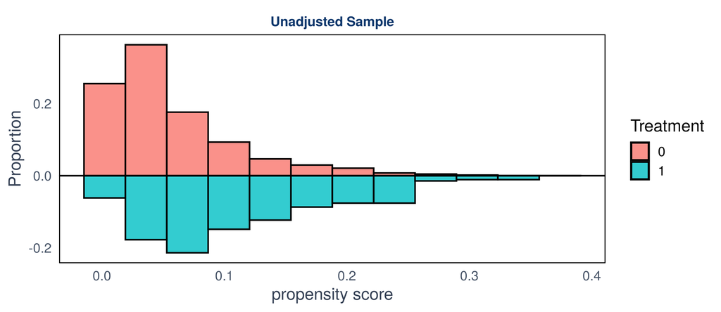

```r
bal.plot(m0, var.name = "distance", type = "histogram", mirror = TRUE) +
  labs(x = "propensity score", title = NULL)
```

- Зеркальная гистограмма PS: сверху одна группа, снизу другая. Ищем зоны, где **у обработанных есть масса, а у контролей нет**
- Здесь контроли есть почти везде, но с $e(X) > 0.3$ их единицы: самые «типичные» обученные будут сопоставлены с немногими похожими контролями

## Шаг 3. Ближайший сосед 1:1 по PS

```r
m1 <- matchit(f_ps, data = tr, method = "nearest", distance = "glm")
m1
```

```
A matchit object
 - method: 1:1 nearest neighbor matching without replacement
 - distance: Propensity score
             - estimated with logistic regression
 - number of obs.: 4629 (original), 552 (matched)
 - target estimand: ATT
 - covariates: log_wage_prev, female, age, years_educ, urban, official, state_owned, tenure, occ, ind
```

Печать объекта — паспорт спецификации: метод, как считалось расстояние, сколько единиц осталось (552 из 4629), эстиманд. Именно это пишут в разделе «Методы».

## Что лежит внутри объекта `matchit`

- match.matrix
- match.data()

```r
head(m1$match.matrix, 4)       # строка = обработанный, ячейка = номер его контроля
```

```
   [,1]
11 "3048"
13 "180"
16 "2339"
17 "3328"
```

```r
table(treat = tr$treat, weight = m1$weights)   # вес 0 = выброшен из анализа
```

```
     weight
treat    0    1
    0 4077  276
    1    0  276
```

`m1$distance` — PS каждого, `m1$weights` — вес, `m1$subclass` — номер пары.

```r
md1 <- match.data(m1)          # только оставшиеся + distance, weights, subclass
md1 |> arrange(subclass) |>
  select(idind, treat, log_wage_prev, female, age, occ, distance, weights, subclass) |>
  head(6)
```

| idind | treat | log_wage_prev | female | age | occ | distance | weights | subclass |
| --- | --- | --- | --- | --- | --- | --- | --- | --- |
| 18983 | 1 | 11.25 | 1 | 38 | рук_спец | 0.213 | 1 | 1 |
| 33487 | 0 | 9.91 | 1 | 31 | рук_спец | 0.212 | 1 | 1 |
| 122 | 0 | 11.59 | 1 | 43 | рук_спец | 0.242 | 1 | 2 |
| 19297 | 1 | 12.35 | 1 | 57 | рук_спец | 0.242 | 1 | 2 |
| 16551 | 0 | 10.90 | 0 | 32 | услуги | 0.024 | 1 | 3 |
| 19324 | 1 | 11.15 | 0 | 42 | рабочие | 0.024 | 1 | 3 |

## Шаг 4. Баланс после мэтчинга

```r
summary(m1, un = FALSE)        # un = FALSE: не повторять таблицу «до»
```

```
Summary of Balance for Matched Data:
              Means Treated Means Control Std. Mean Diff. Var. Ratio eCDF Mean eCDF Max Std. Pair Dist.
distance              0.113         0.113           0.002      1.009     0.000    0.014           0.004
log_wage_prev        10.640        10.638           0.003      1.263     0.021    0.062           0.956
female                0.699         0.717          -0.040          .     0.018    0.018           0.798
age                  40.699        39.409           0.148      0.991     0.037    0.083           1.124
years_educ           15.007        15.076          -0.038      1.153     0.007    0.040           0.603
urban                 0.786         0.812          -0.062          .     0.025    0.025           0.751
official              0.975         0.971           0.023          .     0.004    0.004           0.300
state_owned           0.652         0.620           0.068          .     0.033    0.033           0.647
tenure                9.257         9.178           0.009      1.182     0.022    0.098           1.021
occспец_ср            0.312         0.359          -0.102          .     0.047    0.047           0.696
occрук_спец           0.504         0.449           0.109          .     0.054    0.054           0.572
Sample Sizes:
          Control Treated
All          4353     276
Matched       276     276
Unmatched    4077       0
Discarded       0       0
```

## Как читать вывод `summary(matchit)`

- Вывод R
- С пояснениями

```
              Means Treated Means Control Std. Mean Diff. Var. Ratio eCDF Mean eCDF Max Std. Pair Dist.
distance              0.113         0.113           0.002      1.009     0.000    0.014           0.004
log_wage_prev        10.640        10.638           0.003      1.263     0.021    0.062           0.956
female                0.699         0.717          -0.040          .     0.018    0.018           0.798
age                  40.699        39.409           0.148      0.991     0.037    0.083           1.124
years_educ           15.007        15.076          -0.038      1.153     0.007    0.040           0.603
tenure                9.257         9.178           0.009      1.182     0.022    0.098           1.021
occспец_ср            0.312         0.359          -0.102          .     0.047    0.047           0.696
occрук_спец           0.504         0.449           0.109          .     0.054    0.054           0.572
```

1 · Means Treated / Control

Средние в группах; для факторов — **доля** каждого уровня (`occрук_спец`). После мэтчинга средние контролей взвешены весами мэтчинга

2 · Std. Mean Diff.

(среднее₁ − среднее₀) / SD обработанных **до** мэтчинга — знаменатель один и тот же до и после. Ориентир: $|SMD| < 0.1$, для сильных предикторов $< 0.05$

3 · Var. Ratio

Дисперсия обработанных / контролей. Около 1, норма 0.5–2. Точка «.» у бинарных — не ошибка: их дисперсия определяется долей

4 · eCDF Mean / Max

Средний и максимальный разрыв функций распределения, от 0 до 1. Max = статистика КС. Растут, когда у групп разные хвосты или форма

5 · Std. Pair Dist.

Средняя |разница| **внутри пар** в SD. У `distance` ≈ 0 — пары совпали по PS, но у `age` = 1.12 SD: внутри пары возраст сильно разный

6 · сигналы беды

`age`: SMD = 0.148 > 0.1; `occрук_спец`: 0.109. Баланс по `distance` идеален — и ничего не доказывает. Эту спецификацию **не принимаем**

## Размеры выборок: All, Matched, Unmatched, Discarded, ESS

```r
m_disc <- matchit(f_ps, data = tr, method = "nearest", discard = "both")  # общая поддержка
m_full <- matchit(f_ps, data = tr, method = "full")                        # полный мэтчинг
```

```r
summary(m_disc)$nn
```

```
              Control Treated
All (ESS)        4353     276
All              4353     276
Matched (ESS)     276     276
Matched           276     276
Unmatched        3879       0
Discarded         198       0
```

```r
summary(m_full)$nn
```

```
              Control Treated
All (ESS)        4353     276
All              4353     276
Matched (ESS)     615     276
Matched          4353     276
Unmatched           0       0
Discarded           0       0
```

**Unmatched** — не нашлось пары; **Discarded** — выброшены правилом общей поддержки ещё до мэтчинга. **ESS** = $(\sum w)^2 / \sum w^2$ — скольким невзвешенным наблюдениям эквивалентны взвешенные: full сохранил все 4353 контролей, но «весят» они как 615.

## Квадраты и взаимодействия

```r
s_int <- summary(m1, un = FALSE, interactions = TRUE)$sum.matched
s_int[order(-abs(s_int[, "Std. Mean Diff."])), 1:3] |> head(6) |> round(3)
```

```
                    Means Treated Means Control Std. Mean Diff.
tenure * occуслуги          0.384         0.822          -0.237
tenure * indгосупр          0.844         1.522          -0.214
female * occрабочие         0.014         0.040          -0.212
age * occрук_спец          21.337        17.612           0.169
age                        40.699        39.409           0.148
log_wage_prev * age       433.150       419.334           0.143
```

```r
summary(m1, addlvariables = ~ I(age^2) + I(log_wage_prev^2) + female:years_educ)  # свои термы
```

- `interactions = TRUE` — все квадраты и попарные произведения; выводов много, смотрим **максимум**
- Здесь пары перекошены по стажу внутри групп профессий и отраслей: 27 термов с $|SMD| > 0.1$

## Love plot из `MatchIt`: `plot(summary(m))`

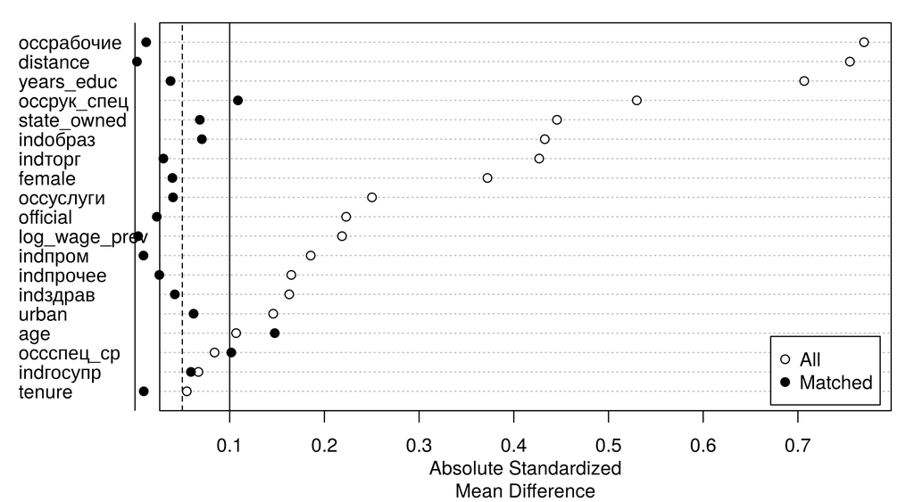

```r
par(mar = c(4, 1, 1, 1))
plot(summary(m1), var.order = "unmatched")
```

Белые точки — до, чёрные — после; пунктир — пороги 0.05 и 0.1. Всё, что правее 0.1 после мэтчинга, — в работу.

## Визуальная диагностика: `type = "jitter"`

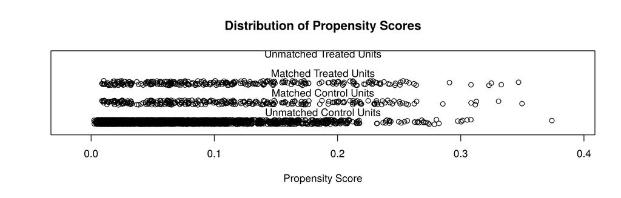

```r
plot(m1, type = "jitter", interactive = FALSE)
```

Каждая точка — человек по PS. Смотрим: нет ли **Unmatched Treated** (здесь пусто — ATT сохранён) и где лежат выброшенные контроли — они должны быть слева, с малым PS.

## `type = "density"`: распределения ковариат

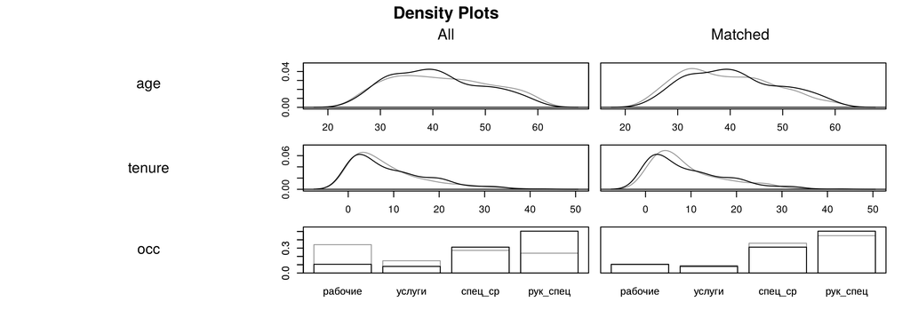

```r
plot(m1, type = "density", which.xs = ~ age + tenure + occ, interactive = FALSE)
```

## `type = "ecdf"` и `type = "qq"`

```r
plot(m1, type = "ecdf", which.xs = ~ age + years_educ + log_wage_prev, interactive = FALSE)
plot(m1, type = "qq",   which.xs = ~ age + years_educ + log_wage_prev, interactive = FALSE)
```

- eCDF
- QQ

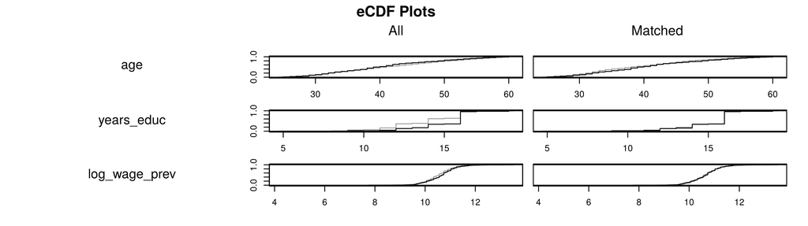

Доля выборки ниже $x$. Линии должны совпадать; наибольший разрыв — `eCDF Max`.

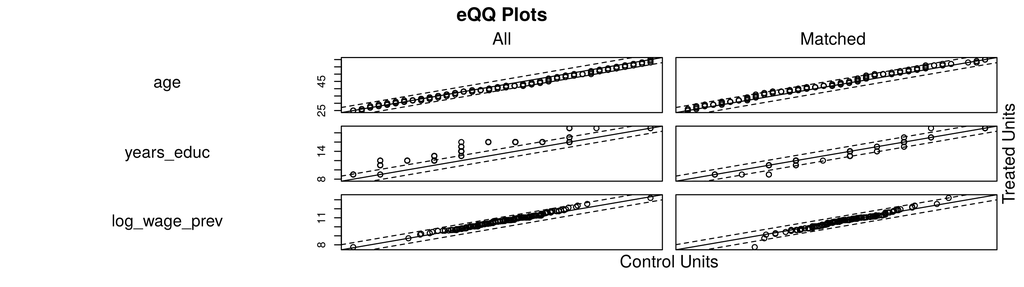

Квантили контролей (x) против обработанных (y). Баланс — точки на диагонали.

## `cobalt::bal.tab()` с порогами

- Таблица
- Итоги
- Код

```
Balance Measures
                  Type Diff.Un V.Ratio.Un Diff.Adj        M.Threshold V.Ratio.Adj  V.Threshold
distance      Distance   0.755      2.058    0.002     Balanced, <0.1       1.009 Balanced, <2
log_wage_prev  Contin.   0.219      0.916    0.003     Balanced, <0.1       1.263 Balanced, <2
female          Binary   0.171          .   -0.018     Balanced, <0.1           .
age            Contin.  -0.107      0.863    0.148 Not Balanced, >0.1       0.991 Balanced, <2
years_educ     Contin.   0.707      0.658   -0.038     Balanced, <0.1       1.153 Balanced, <2
urban           Binary   0.060          .   -0.025     Balanced, <0.1           .
official        Binary   0.035          .    0.004     Balanced, <0.1           .
state_owned     Binary   0.212          .    0.033     Balanced, <0.1           .
tenure         Contin.   0.055      1.067    0.009     Balanced, <0.1       1.182 Balanced, <2
occ_рук_спец    Binary   0.265          .    0.054     Balanced, <0.1           .
ind_образ       Binary   0.200          .    0.033     Balanced, <0.1           .
```

```
Balance tally for mean differences
                   count
Balanced, <0.1        18
Not Balanced, >0.1     1

Variable with the greatest mean difference
 Variable Diff.Adj        M.Threshold
      age    0.148 Not Balanced, >0.1
```

как читать

`Diff.Un` / `Diff.Adj` — до и после. **Для бинарных** cobalt по умолчанию печатает **сырую разницу долей**, а не SMD (`female`: 0.171 против 0.372 в `summary()`); `binary = "std"` выравнивает. `M.Threshold` — прошла ли переменная порог; ниже — сводка и худшая переменная

```r
bal.tab(m1, un = TRUE, thresholds = c(m = .1, v = 2))   # m — средние, v — дисперсии
bal.tab(m1, stats = c("m", "v", "ks"), binary = "std", int = TRUE)  # + КС, взаимодействия
```

## `cobalt::love.plot()`

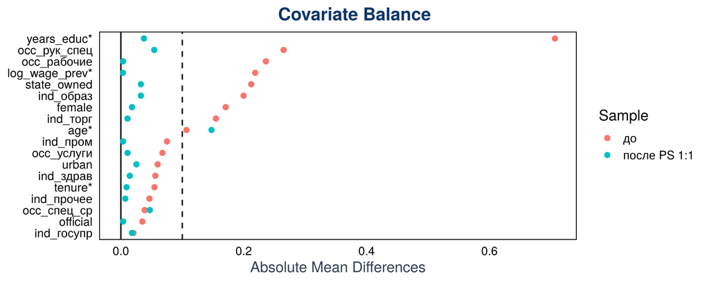

```r
love.plot(m1, stars = "std", abs = TRUE, drop.distance = TRUE, var.order = "unadjusted",
          thresholds = c(m = .1), sample.names = c("до", "после PS 1:1"))
```

`stars = "std"` помечает звёздочкой переменные со **стандартизированной** разницей (непрерывные); у бинарных — сырая разница долей. Подпись оси надо пояснить в тексте.

## `cobalt::bal.plot()`: одна переменная целиком

```r
bal.plot(m1, var.name = "distance", which = "both", type = "histogram", mirror = TRUE)
bal.plot(m1, var.name = "age", which = "both")        # which = "both": до и после
```

- PS до и после
- Возраст

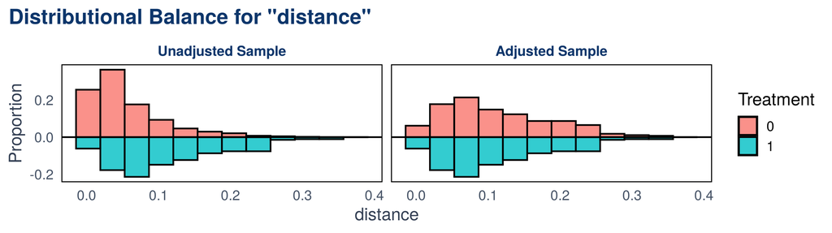

После мэтчинга гистограммы PS совпадают — так и должно быть при PS-мэтчинге, это **не проверка** баланса ковариат.

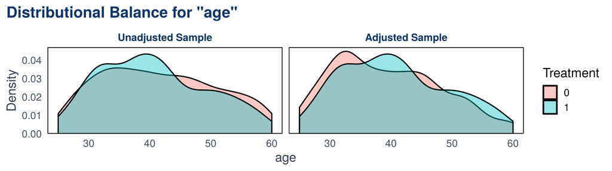

Плотности возраста после мэтчинга по-прежнему расходятся — то, что показал SMD = 0.15.

## Шаг 4 → снова шаг 3: калипер не лечит

```r
cal <- map(c(0.2, 0.05, 0.01), \(w) matchit(f_ps, data = tr, method = "nearest", caliper = w))
bind_rows(bal_row(m1), map(cal, bal_row)) |>
  mutate(`калипер, SD PS` = c("нет", "0.2", "0.05", "0.01"), .before = 1)
```

| калипер, SD PS | обраб. | ESS контр. | max \|SMD\| | max \|SMD\| взаим. |
| --- | --- | --- | --- | --- |
| нет | 276 | 276 | 0.148 | 0.237 |
| 0.2 | 275 | 275 | 0.143 | 0.238 |
| 0.05 | 268 | 268 | 0.157 | 0.244 |
| 0.01 | 255 | 255 | 0.151 | 0.256 |

- Чем уже калипер, тем **меньше обработанных** — и баланс не улучшается: пары и так совпадают по PS, но не по возрасту
- Это аргумент King & Nielsen (2019): сужение PS-калипера может даже ухудшать баланс ковариат. Нужен другой **способ измерять расстояние**

## Махаланобис: расстояние по ковариатам

```r
m_maha <- map(1:4, \(k) matchit(f_ps, data = tr, method = "nearest",
                                distance = "mahalanobis", ratio = k))
bind_rows(map(m_maha, bal_row)) |> mutate(`контролей на обученного` = 1:4, .before = 1)
```

| контролей на обученного | обраб. | ESS контр. | max \|SMD\| | max \|SMD\| взаим. |
| --- | --- | --- | --- | --- |
| 1 | 276 | 276 | 0.042 | 0.053 |
| 2 | 276 | 552 | 0.049 | 0.059 |
| 3 | 276 | 828 | 0.082 | 0.091 |
| 4 | 276 | 1104 | 0.123 | 0.131 |

- Пары теперь близки по **всем** $X$ сразу: max |SMD| падает с 0.148 до 0.042, взаимодействия тоже в норме
- 1:2 удваивает ESS почти без потери баланса; 1:4 уже хуже — четвёртый сосед далеко. **Выбираем 1:2**

## Другие ручки: exact, с заменой, optimal

```r
m_ex  <- matchit(f_ps, data = tr, method = "nearest", caliper = 0.2,
                 exact = ~ female + occ)                           # точно по полу и профессии
m_r3  <- matchit(f_ps, data = tr, method = "nearest", ratio = 3, replace = TRUE)
```

```r
m_opt <- matchit(f_ps, data = tr, method = "optimal")              # optmatch, ~10 сек
```

| спецификация | обраб. | ESS контр. | max \|SMD\| | max \|SMD\| взаим. |
| --- | --- | --- | --- | --- |
| PS + exact (пол, профессия) + калипер | 274 | 274 | 0.081 | 0.119 |
| PS 1:3 с заменой | 276 | 539 | 0.052 | 0.131 |
| optimal PS 1:1 | 276 | 276 | 0.211 | 0.249 |

Optimal минимизирует **сумму расстояний по PS** — а не дисбаланс ковариат, поэтому не обязан быть лучше жадного.

## Полный мэтчинг и подклассификация

```r
m_full_ate <- matchit(f_ps, data = tr, method = "full", estimand = "ATE")
m_sub      <- matchit(f_ps, data = tr, method = "subclass", subclass = 10)
```

| спецификация | обраб. | ESS контр. | max \|SMD\| | max \|SMD\| взаим. |
| --- | --- | --- | --- | --- |
| full, ATT | 276 | 615 | 0.056 | 0.164 |
| full, ATE | 276 | 4261 | 0.214 | 0.241 |
| подклассы по PS, 10 | 276 | 1955 | 0.028 | 0.103 |

- **Full** держит всех; веса делают работу. Для ATE баланс нужен с **обеих** сторон — здесь он хуже
- **Подклассы**: `subclass = 6` по умолчанию — произвольное число; пробуйте больше. `summary(m_sub, subclass = TRUE)` — баланс внутри каждого подкласса

## CEM: огрубить и сравнивать точно

- По умолчанию
- Свои границы

```r
m_cem <- matchit(f_ps, data = tr, method = "cem")          # границы по правилу Стёрджеса
summary(m_cem)$nn
```

```
              Control Treated
All (ESS)      4353.0     276
All            4353.0     276
Matched (ESS)    50.1      43
Matched          61.0      43
Unmatched      4292.0     233
Discarded         0.0       0
```

Проклятие размерности: из 276 обученных пару нашли только 43.

```r
m_cem2 <- matchit(f_ps, data = tr, method = "cem",
                  cutpoints = list(log_wage_prev = 8, age = 6, tenure = c(2, 5, 10),
                                   years_educ = c(11.5, 13.5, 15.5)),       # число или границы
                  grouping = list(ind = list(c("пром", "торг", "прочее"),
                                             c("образ", "здрав", "госупр"))))
summary(m_cem2)$nn
```

```
              Control Treated
All (ESS)        4353     276
All              4353     276
Matched (ESS)     347     182
Matched           552     182
Unmatched        3801      94
Discarded           0       0
```

Грубее ячейки → больше пар, но внутри ячейки люди менее похожи: 182 обученных, max |SMD| = 0.144.

## Генетический мэтчинг

```r
set.seed(5)
m_gen <- matchit(f_ps, data = tr, method = "genetic", distance = "glm",
                 pop.size = 50)              # Matching + rgenoud; ~2 мин, на практике pop.size ≥ 200
```

```r
bal_row(m_gen)
```

| обраб. | ESS контр. | max \|SMD\| | max \|SMD\| взаим. |
| --- | --- | --- | --- |
| 276 | 276 | 0.01 | 0.049 |

- Генетический алгоритм подбирает **веса ковариат** в обобщённом расстоянии Махаланобиса (плюс PS), максимизируя баланс (по умолчанию — наименьшее p-значение тестов баланса)
- Баланс почти идеальный, но это самый медленный метод; при большом `pop.size` — минуты и часы

## Сравнение спецификаций

- Результат
- Код

| спецификация | эстим. | обраб. | ESS контр. | max \|SMD\| | max \|SMD\| взаим. | эффект [95% ДИ] |
| --- | --- | --- | --- | --- | --- | --- |
| PS 1:1 | ATT | 276 | 276 | 0.148 | 0.237 | 0.039 [-0.034; 0.112] |
| PS 1:1, калипер 0.2 | ATM | 275 | 275 | 0.143 | 0.238 | 0.039 [-0.035; 0.112] |
| PS + exact + калипер | ATM | 274 | 274 | 0.081 | 0.119 | -0.032 [-0.099; 0.035] |
| PS 1:3 с заменой | ATT | 276 | 539 | 0.052 | 0.131 | 0.035 [-0.012; 0.081] |
| optimal PS 1:1 | ATT | 276 | 276 | 0.211 | 0.249 | 0.018 [-0.047; 0.083] |
| Махаланобис 1:1 | ATT | 276 | 276 | 0.042 | 0.053 | 0.027 [-0.032; 0.086] |
| Махаланобис 1:2 ★ | ATT | 276 | 552 | 0.049 | 0.059 | 0.031 [-0.020; 0.081] |
| генетический 1:1 | ATT | 276 | 276 | 0.010 | 0.049 | 0.027 [-0.033; 0.088] |
| full | ATT | 276 | 615 | 0.056 | 0.164 | 0.048 [-0.002; 0.097] |
| full | ATE | 276 | 4261 | 0.214 | 0.241 | 0.045 [-0.011; 0.101] |
| подклассы, 10 | ATT | 276 | 1955 | 0.028 | 0.103 | 0.049 [-0.006; 0.104] |
| CEM по умолчанию | ATM | 43 | 50 | 0.036 | 0.036 | мало данных |
| CEM, свои границы | ATM | 182 | 347 | 0.144 | 0.203 | 0.020 [-0.047; 0.088] |

```r
specs <- list("PS 1:1" = list(m1, "ATT"), "Махаланобис 1:2 ★" = list(m_final, "ATT"),
              ...)                              # все объекты matchit с предыдущих слайдов
imap(unname(specs), \(s, i) bind_cols(tibble(`спецификация` = names(specs)[i]),
                                      bal_row(s[[1]]),          # баланс: summary() без исхода
                                      tibble(`эффект` = ci_txt(att_est(s[[1]]))))) |> bind_rows()
```

## Как читать таблицу сравнения

выбор — слева

Спецификацию выбираем по столбцам **баланса** и ESS — они посчитаны без исхода. Столбец эффекта на этом этапе закрыт; здесь он открыт только ради урока

баланс vs размер

Махаланобис 1:2 и генетический дают лучший баланс при сохранении **всех** обработанных; full и подклассы — больше ESS, но хуже взаимодействия

эстиманд

Калипер, exact и CEM выбросили обработанных → **ATM**: эффект для «сопоставимых», а не всех обученных. CEM по умолчанию оставил так мало, что оценивать нечего

Три лучше всего сбалансированные спецификации (Махаланобис 1:1 и 1:2, генетический) дают эффект от 0.027 до 0.031 лога, и все ДИ накрывают ноль. Устойчивость к выбору метода — хороший знак; разброс между **плохо** сбалансированными — плохой.

## Love plot: спецификации рядом

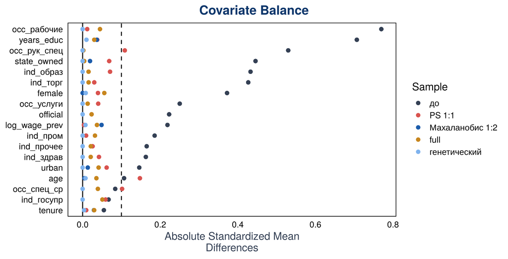

```r
love.plot(f_ps, data = tr, binary = "std", abs = TRUE, thresholds = c(m = .1),
          weights = list(ps = m1, maha = m_final, full = m_full, gen = m_gen),
          var.order = "unadjusted", position = "right",
          colors = unname(pal[c("charcoal", "coral", "indigo", "sage", "lavender")]),
          sample.names = c("до", "PS 1:1", "Махаланобис 1:2", "full", "генетический"))
```

## Кого выбросили

CEM со своими границами потерял 94 обученных. Кто они?

```r
tr |> mutate(matched = m_cem2$weights > 0) |> filter(treat == 1) |>
  group_by(matched) |>
  summarise(n = n(), female = mean(female), years_educ = mean(years_educ),
            wage_prev = mean(log_wage_prev), state = mean(state_owned),
            urban = mean(urban), tenure = mean(tenure))
```

| matched | n | female | years_educ | wage_prev | state | urban | tenure |
| --- | --- | --- | --- | --- | --- | --- | --- |
| FALSE | 94 | 0.606 | 14.5 | 10.6 | 0.606 | 0.670 | 6.28 |
| TRUE | 182 | 0.747 | 15.3 | 10.6 | 0.676 | 0.846 | 10.80 |

- Выпадают люди с редкими сочетаниями признаков — для них нет похожих контролей в той же ячейке
- Эффект после CEM — для **сопоставимых** обученных; о выброшенных данные молчат, и это надо написать

## Шаг 5. Оценка эффекта: стандартный случай

```r
md <- match.data(m_final)                             # 276 обученных + 552 контроля
fit <- lm(log_wage ~ treat * (log_wage_prev + female + age + years_educ + urban +
                                official + state_owned + tenure + occ + ind),
          data = md, weights = weights)               # коэффициенты НЕ читаем
att <- avg_comparisons(fit, variables = "treat",      # g-computation по treat
                       vcov = ~subclass,              # кластеры = пары
                       newdata = subset(md, treat == 1),  # усредняем по обработанным → ATT
                       wts = "weights")               # с весами мэтчинга
print(att)
```

```
  Term Contrast Estimate Std. Error    z Pr(>|z|)   S  2.5 % 97.5 %
 treat    1 - 0   0.0309      0.027 1.14    0.252 2.0 -0.022 0.0839

Columns: term, contrast, estimate, std.error, statistic, p.value, s.value, conf.low, conf.high
Type:  response
```

## Как читать вывод `avg_comparisons()`

- Вывод R
- С пояснениями

```
  Term Contrast Estimate Std. Error    z Pr(>|z|)   S  2.5 % 97.5 %
 treat    1 - 0   0.0309      0.027 1.14    0.252 2.0 -0.022 0.0839

Columns: term, contrast, estimate, std.error, statistic, p.value, s.value, conf.low, conf.high
Type:  response
```

1 · Term / Contrast

`treat`, `1 - 0`: для каждого обработанного предсказание при `treat = 1` минус при `treat = 0`, усреднённое с весами

2 · Estimate

ATT в единицах исхода: 0.031 лога ≈ 3.1% к зарплате ($e^{b} - 1$)

3 · Std. Error

Дельта-метод с кластерной ковариацией по `subclass` (паре): 0.027

4 · z, Pr(>|z|), S

Нормальная аппроксимация. S = $-\log_2 p$ — «бит информации против нуля»: 2 бита — как 2 орла подряд у честной монеты

5 · 2.5 % / 97.5 %

95% ДИ: [-0.022; 0.084]. Сообщаем его, а не звёздочки

6 · сигналы беды

Нет `newdata` → среднее по всей выборке, не ATT. Нет `wts` → веса потеряны. Нет `vcov` → обычные SE. Интерпретация коэффициентов `lm()` — «ошибка второй таблицы»

## Потенциальные исходы: `avg_predictions()`

```r
avg_predictions(fit, variables = "treat", vcov = ~subclass,
                newdata = subset(md, treat == 1), wts = "weights") |> print()
```

```
 treat Estimate Std. Error   z Pr(>|z|)   S 2.5 % 97.5 %
     0     10.7     0.0132 811   <0.001 Inf  10.6   10.7
     1     10.7     0.0250 427   <0.001 Inf  10.7   10.8

Columns: treat, estimate, std.error, statistic, p.value, s.value, conf.low, conf.high
Type:  response
```

- Строка `treat = 1`: средний предсказанный log зарплаты обученных — **с** обучением; `treat = 0` — их же контрфакт **без** обучения
- Разность строк = ATT с предыдущего слайда. Так корректно только если **все** ковариаты взаимодействуют с `treat` в модели исхода

## Какие ошибки и почему

```r
se_tab <- map(list(`обычные (как частотные веса)` = TRUE, `робастные HC3` = "HC3",
                   `кластерные по паре` = ~subclass),
              \(v) avg_comparisons(fit, variables = "treat", vcov = v,
                                   newdata = subset(md, treat == 1), wts = "weights"))
imap_dfr(se_tab, \(a, n) tibble(`ошибки` = n, se = a$std.error, `95% ДИ` = ci_txt(a)))
```

| ошибки | se | 95% ДИ |
| --- | --- | --- |
| обычные (как частотные веса) | 0.026 | 0.031 [-0.020; 0.081] |
| робастные HC3 | 0.030 | 0.031 [-0.027; 0.089] |
| кластерные по паре | 0.027 | 0.031 [-0.022; 0.084] |

- Партнёры по паре похожи по $X$, а значит и по исходу — наблюдения **не независимы**. Abadie & Spiess (2022): кластерные по паре ошибки после мэтчинга без возвращения корректны
- При весах ≠ 1 «обычные» ошибки `lm()` неверны всегда: они считают веса частотами

## Поправки к стандартному случаю

- Таблица
- Код: с возвращением
- Код: веса

| Ситуация | Данные | vcov | newdata |
| --- | --- | --- | --- |
| пары без возвращения (nearest, optimal, genetic, 1:k) | `match.data()` | `~subclass` | обработанные |
| **с возвращением** (`replace = TRUE`) | `get_matches()` | `~subclass + id` | обработанные |
| full matching | `match.data()` | `~subclass` | обработанные |
| CEM, exact, подклассы (веса) | `match.data()` | `"HC3"` | обработанные |
| любой метод для **ATE** | как выше | как выше | не указывать (вся выборка) |

Бинарный исход: `glm(..., family = quasibinomial())`, дальше тот же `avg_comparisons()` — получится разность рисков; `comparison = "lnratioavg", transform = "exp"` — отношение рисков.

```r
gm <- get_matches(m_r3)            # строка = единица × пара: контроль повторяется
c(строк = nrow(gm), уникальных = n_distinct(gm$id))
```

```
     строк уникальных
      1104        955
```

```r
fit_r3 <- lm(f_y, data = gm, weights = weights)
avg_comparisons(fit_r3, variables = "treat", vcov = ~subclass + id,  # пара + человек
                newdata = subset(gm, treat == 1), wts = "weights") |> print()
```

```
  Term Contrast Estimate Std. Error    z Pr(>|z|)   S   2.5 % 97.5 %
 treat    1 - 0   0.0348     0.0278 1.25    0.211 2.2 -0.0197 0.0894

Columns: term, contrast, estimate, std.error, statistic, p.value, s.value, conf.low, conf.high
Type:  response
```

```r
md_sub <- match.data(m_sub)                                 # подклассы: кластеров мало
fit_sub <- lm(f_y, data = md_sub, weights = weights)
avg_comparisons(fit_sub, variables = "treat", vcov = "HC3",
                newdata = subset(md_sub, treat == 1), wts = "weights")

md_ate <- match.data(m_full_ate)                            # full для ATE: newdata не нужен
fit_ate <- lm(f_y, data = md_ate, weights = weights)
avg_comparisons(fit_ate, variables = "treat", vcov = ~subclass, wts = "weights")
```

## Лестница оценок

| метод | est | se | 95% ДИ |
| --- | --- | --- | --- |
| наивная разница | 0.160 | 0.039 | [0.083; 0.237] |
| регрессия с контролями | 0.063 | 0.027 | [0.010; 0.116] |
| PS 1:1, разница средних | 0.058 | 0.055 | [-0.050; 0.165] |
| PS 1:1 + g-computation | 0.039 | 0.037 | [-0.034; 0.112] |
| Махаланобис 1:2, разница средних | 0.055 | 0.042 | [-0.027; 0.137] |
| Махаланобис 1:2 + g-computation ★ | 0.031 | 0.027 | [-0.022; 0.084] |

Наивные 0.16 лога превращаются в 0.031: большая часть «эффекта обучения» — это то, что учатся люди, которые и так зарабатывали больше. Ковариаты в модели исхода сдвигают обе мэтчинг-оценки вниз: даже после Махаланобиса по самому сильному предиктору — прошлой зарплате — остались SMD = 0.049 и Var. Ratio = 1.54. Регрессия по всей выборке (0.063) усредняет сравнения с другими весами (лекция 4) и опирается на линейную экстраполяцию.

## Кого мы сравниваем: тройки

```r
md |> filter(subclass %in% levels(subclass)[1:2]) |> arrange(subclass, desc(treat)) |>
  select(subclass, treat, female, age, years_educ, occ, ind, tenure, log_wage_prev, log_wage) |>
  mutate(across(c(log_wage_prev, log_wage), ~ round(.x, 2)))
```

| subclass | treat | female | age | years_educ | occ | ind | tenure | log_wage_prev | log_wage |
| --- | --- | --- | --- | --- | --- | --- | --- | --- | --- |
| 1 | 1 | 1 | 38 | 16 | рук_спец | образ | 14 | 11.2 | 11.4 |
| 1 | 0 | 1 | 36 | 16 | рук_спец | образ | 4 | 10.7 | 10.3 |
| 1 | 0 | 1 | 46 | 16 | рук_спец | образ | 14 | 10.8 | 10.7 |
| 2 | 1 | 1 | 57 | 16 | рук_спец | здрав | 6 | 12.3 | 12.2 |
| 2 | 0 | 1 | 52 | 16 | рук_спец | здрав | 17 | 11.2 | 11.2 |
| 2 | 0 | 1 | 40 | 16 | рук_спец | здрав | 4 | 12.6 | 11.9 |

Прозрачность мэтчинга: любую тройку можно показать и обсудить. У регрессии такого «списка сравнений» нет. Пол и профессия совпали без `exact` — Махаланобис сам этого добивается.

## Как писать результат

шаблон

«Для оценки среднего эффекта профобучения на прошедших его (ATT) использован мэтчинг ближайшего соседа 2:1 без возвращения по расстоянию Махаланобиса по 10 ковариатам, измеренным до обучения, включая log зарплаты в 2018 г. (`MatchIt` 4.5.5). Сохранены все 276 обученных и 552 контролей; после мэтчинга все |SMD| ≤ 0.049, для квадратов и попарных взаимодействий — ≤ 0.059. Эффект оценён g-computation по линейной модели с взаимодействиями воздействия и ковариат, с весами мэтчинга и кластерными по тройкам ошибками (`marginaleffects::avg_comparisons`). ATT = **0.031** (s.e. 0.027; 95% ДИ [-0.022; 0.084]), т.е. около 3% к зарплате; ДИ включает ноль. Наивная разница — 0.16.»

- Обязательно назвать: эстиманд, допущение (отбор только по наблюдаемым), какие спецификации пробовали и почему выбрана эта, тип ошибок
- Не писать «обучение не влияет на зарплату»: ДИ допускает и ноль, и эффект порядка 9%

## Что показать в статье

1 · спецификация

Вывод `print(m)`: метод, расстояние (как оценён PS), калипер, `exact`, `ratio`, `replace`, `discard`. Какие ещё пробовали и почему отказались

2 · таблица баланса

До/после: средние, SMD, Var. Ratio, eCDF Max по каждой ковариате (`summary()` или `bal.tab()`). Отдельной строкой — max |SMD| по квадратам и взаимодействиям

3 · Love plot

`love.plot()` с порогом 0.1; при нескольких спецификациях — на одном графике. Для ключевых переменных — `bal.plot()`

4 · размеры выборок

All / Matched / Unmatched / Discarded и ESS; если выброшены обработанные — кто они и как меняется эстиманд

5 · оценка

Модель исхода, g-computation, тип ошибок (кластеры по паре), пакеты и функции. ATT, s.e., 95% ДИ

6 · чего не делать

Не показывать коэффициенты ковариат модели исхода; не давать p-значения баланса; не прятать, сколько спецификаций перепробовано

# Как ошибаются

## Ошибки в дизайне

ошибка 1

### Баланс по p-значениям

**Как правильно:** SMD, Var. Ratio, eCDF. t-тест после мэтчинга «не отвергает» просто потому, что $n$ уменьшилось

ошибка 2

### Смотреть на эффект при выборе метода

**Как правильно:** выбирать по балансу и ESS; исход открыть один раз. Перебор до «значимости» — p-hacking

ошибка 3

### Мэтчинг на переменных после воздействия

**Как правильно:** только до воздействия (лекция 3, «плохие контроли»). Зарплата 2019 г. или должность после курса — нельзя

ошибка 4

### «Баланс по PS идеален — значит, всё хорошо»

**Как правильно:** PS сбалансируется почти при любом PS-мэтчинге. Проверять ковариаты, их квадраты и взаимодействия

## Ошибки в оценке

ошибка 5

### Забыть веса

**Как правильно:** `weights = weights` в `lm()` и `wts = "weights"` в `avg_comparisons()` — всегда, даже при 1:1. Для full, CEM, подклассов, 1:k и замены без них мэтчинга просто нет

ошибка 6

### Обычные ошибки `lm()`

**Как правильно:** `vcov = ~subclass`; с возвращением — `get_matches()` и `~subclass + id`; CEM и подклассы — `"HC3"`

ошибка 7

### Коэффициент при `treat` = ATT

**Как правильно:** при взаимодействиях это эффект при $X = 0$. Только g-computation с `newdata` = обработанные

ошибка 8

### Молча выбросить обработанных

**Как правильно:** калипер, `discard`, CEM меняют эстиманд на ATM. Показать, сколько и кого потеряли

## Чек-лист

- Эстиманд (ATT / ATC / ATE) назван **до** мэтчинга; ковариаты — из DAG, все до воздействия, есть предшествующий исход
- Исходный дисбаланс: `matchit(method = NULL)` + `summary()`; общая поддержка — `bal.plot(distance)` / `type = "jitter"`
- Перепробовано несколько спецификаций (расстояние, `ratio`, калипер, full, CEM); выбор — по балансу и ESS, без исхода
- $|SMD| < 0.1$ (0.05 для сильных предикторов), Var. Ratio 0.5–2, eCDF; квадраты и взаимодействия; графики ключевых переменных
- Размеры выборок и ESS; если выброшены обработанные — кто они
- Оценка: g-computation, веса, взаимодействия с `treat`, кластерные ошибки по паре
- Анализ чувствительности к скрытому конфаундеру (лекция 17)

# Мини-задача

## Задание к следующему занятию

1. Повторите весь рабочий процесс (шаги 2–5) для 2016 или 2023 года. Какая спецификация выигрывает по балансу? Устойчив ли ATT?
2. Уберите `log_wage_prev` из формулы, но проверьте баланс по нему через `addlvariables`. Что произошло с балансом и с оценкой?
3. Добавьте к Махаланобису 1:2 калипер на прошлую зарплату: `caliper = c(log_wage_prev = 0.1)`. Ушёл ли Var. Ratio ≈ 1.5? Чем пришлось заплатить? Затем PS на шкале логита: `link = "linear.logit", caliper = 0.2, m.order = "closest"` — добавьте обе строки в таблицу сравнения
4. Полный мэтчинг для ATE: что меняется в `avg_comparisons()`? Почему ATE и ATT здесь могут различаться?
5. Найдите границы CEM, при которых сохраняется не меньше 250 обученных и max |SMD| < 0.1
6. Оцените эффект **курения** (`smokes`) на `poor_health` (2019). Нарисуйте love plot, напишите результат по шаблону и объясните, почему это всё ещё не причинный эффект

# Литература

## Что прочитать

- Greifer N. Виньетки `MatchIt` 4.5: «Getting Started», «Matching Methods», «Assessing Balance», «Estimating Effects» — `vignette(package = "MatchIt")`; `cobalt`: «cobalt», «love.plot». **Основа этой лекции**
- Ho D., Imai K., King G., Stuart E. (2007). Matching as Nonparametric Preprocessing for Reducing Model Dependence in Parametric Causal Inference. *Political Analysis* 15(3)
- Ho D., Imai K., King G., Stuart E. (2011). MatchIt: Nonparametric Preprocessing for Parametric Causal Inference. *Journal of Statistical Software* 42(8)
- Stuart E. (2010). Matching Methods for Causal Inference: A Review and a Look Forward. *Statistical Science* 25(1)
- Greifer N., Stuart E. (2021). Matching Methods for Confounder Adjustment: An Addition to the Epidemiologist’s Toolbox. *Epidemiologic Reviews* 43(1)
- Rosenbaum P., Rubin D. (1983). The Central Role of the Propensity Score in Observational Studies. *Biometrika*
- King G., Nielsen R. (2019). Why Propensity Scores Should Not Be Used for Matching. *Political Analysis*
- Abadie A., Spiess J. (2022). Robust Post-Matching Inference. *JASA* — почему кластерные ошибки по паре
- Cunningham S. *The Mixtape*, гл. 5 «Matching and Subclassification»

Каузальный анализ в R · RLMS-HSE · К. Аванесян

← К программе курса